# Reproducible Research_ Final Project

Sang Luong

5/26/2022

## 1. Introduction

- The project aims to reproduce Econometric Analyst in Advanced econometrics course in which I will investigate the nexus between **Corruption** and **foreign direct investment (FDI)** in the context of a panel data of the Middle East and North Africa (MENA) countries in period 2003-2009.
- For the project: **Reproduction** (2003-2009) -> **Replication** (extending the years 2003-2013) -> **Compare results**
- The econometrics model is inspired by paper [Heba E. Helmy (2013). The impact of corruption on FDI: is MENA an exception?](https://doi.org/10.1080/02692171.2012.752445)
- In general, there are two schools of thought on Corruption-FDI relationship: **“Grease”** versus **“sand”** theories:

|  | **Grease the wheel** | **Sand the wheel** |
| --- | --- | --- |
| Definition | Corruption allows economic agents to overcome the inefficiencies created by ill-functioning institutions | Corruption affects the performance of MNCs and is a disincentivizing factor for FDI |
| References | Lui (1985), Tullock (1996), Egger and Winner (2005). | Mauro (1995), Mo (2001), Chang and Hao (2017) |

## 2. Data Processing

### 2.1 Data description

| Variable | Abb | Definition | Source |
| --- | --- | --- | --- |
| Foreign direct investment | FDI | Net FDI inflows into country | World Bank |
| Corruption perception index | CPI | Measure the corruption in each country. Range from 0 (highly corrupt) - 10 (highly clean) | Transparency International |
| GDP per capita (current US$) | PCGDP | Gross domestic product divided by midyear population | World Bank |
| Openess | OPEN | The value of exports plus the value of imports divided by GDP | World Bank |
| Fiscal Freedom | FISCAL | The tax burden imposed by government. Range from 0-100 | Heritage’s Index of Economic Freedom |
| Investment Freedom | FREEINV | The magnitude of constraints imposed by a country on the flow of investment capital. Range from 0-100 | Heritage’s Index of Economic Freedom |

### 2.2 Data Processing

- Originally, there are 21 MENA countries: Algeria, Bahrain, Egypt, Iran, Israel, Jordan, Kuwait, Lebanon, Libya, Morocco, Oman, Qatar, Saudi Arabia, Syria, Tunisia, United Arab Emirates, Yemen, Djibouti, Iraq, Palestine, Turkey. However, Yemen, Djibouti, Iraq, Palestine, Turkey are excluded in data due to the missing value for many years. $\checkmark$
- In most studies in the empirical literature on FDI flows, the logarithm for investment flows and the independent variables is used.Since some of the observations for FDI are negative, we transform these variables using the following procedure: $y = ln(x + \sqrt{x^2+1})$, where Y is a new observation obtained after transforming the initial negative observation x. $\checkmark$
- To avoid simultaneity, all explanatory variables are lagged one year in order with the dependent variable.$\checkmark$
- *In orginal paper, Helmy (2013) used the fixed effects with cross-section weights estimation. However, the author did not clarify the weight parameters in the paper.* $\otimes$

```
##    Country year    LNCPI  LNPCGDP      OPEN FISCAL FREEINV    LNFDI
## 1  Algeria 2003 3.258097 7.651301  62.12477   65.2      70 21.29396
## 2  Algeria 2004 3.295837 7.867177  65.70142   74.1      70 21.56138
## 3  Algeria 2005 3.332205 8.043373  71.27860   73.9      50 22.02672
## 4  Algeria 2006 3.433987 8.154417  70.73001   73.9      50 21.93921
## 5  Algeria 2007 3.401197 8.281601  71.93813   73.8      50 22.38666
## 6  Algeria 2008 3.465736 8.501802  76.68452   77.0      40 22.42690
## 7  Bahrain 2003 4.110874 9.562548 128.09158   99.5      50 21.27174
## 8  Bahrain 2004 4.060443 9.670704 140.73731   99.5      50 21.46387
## 9  Bahrain 2005 4.060443 9.795869 148.31353   99.5      50 22.48617
## 10 Bahrain 2006 4.043051 9.868249 147.10418   99.4      50 21.97963
```

## 3. Regression on Panel Data Model

### 3.1 Descriptive statistic

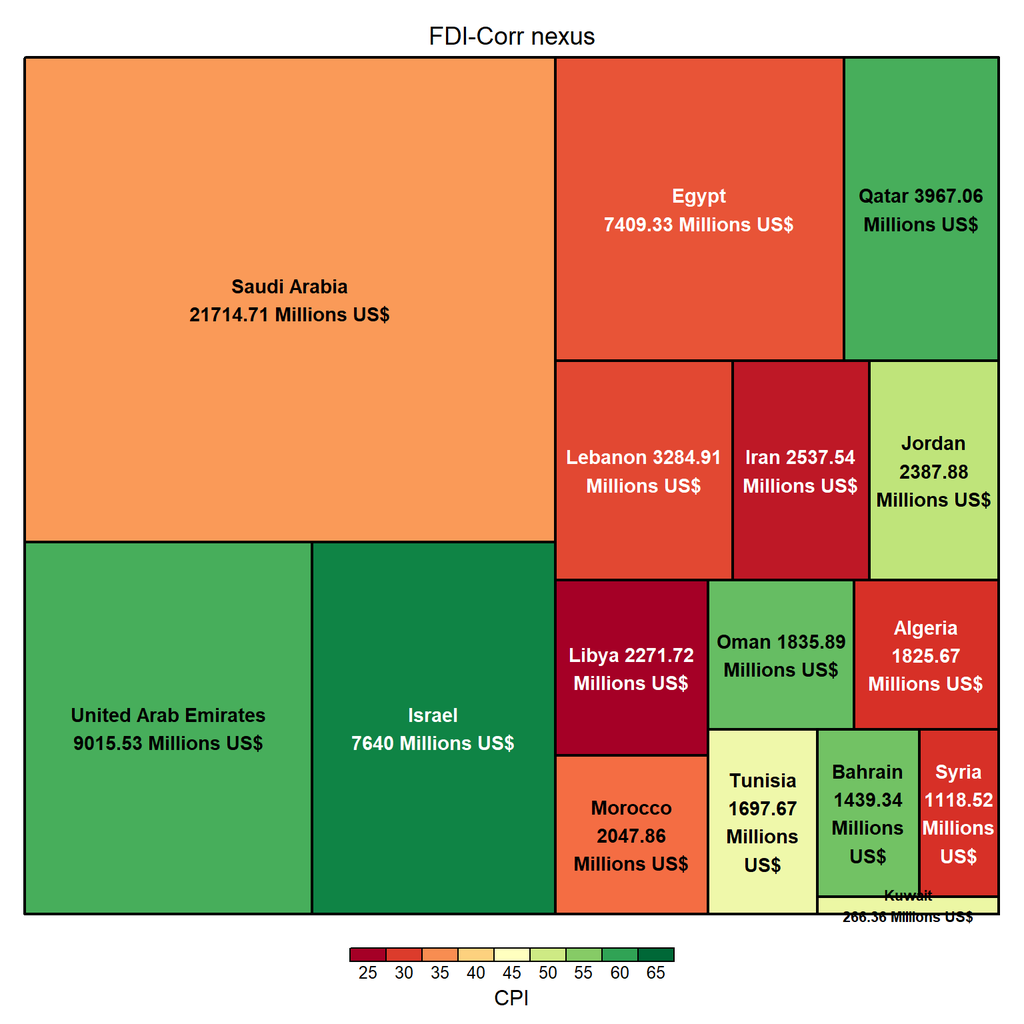

### 3.2 Panel data model

- **The process of using Panel data Model**

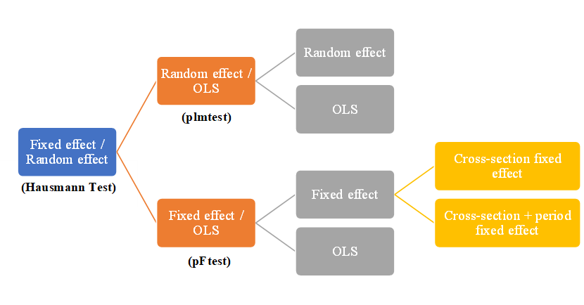

The process of using Panel data Model

- **Main model**

$$LNFDI = \beta_{0i,t} + \beta_1LNCPI_{i,t-1} + \beta_2LNPCGDP_{i,t-1} + \beta_3OPEN_{i,t-1} + \beta_4FISCAL_{i,t-1} + \beta_5FREEINV_{i,t-1} + \mu_i + \lambda_t + \epsilon_{i,t}$$
In which:
- LNFDI: dependent variable
- LNCPI, LNPCGDP, OPEN, FISCAL, FREEINV: independent and control variables
- $\mu_i$: the unobservable individual effect
- $\lambda_t$: the unobservable time effect
- $\epsilon_{i,t}$: a random disturbance

- **Selecting appropriate model**

| Variable | MENA 2003-2009 |  |  | MENA 2003-2013 |  |
| --- | --- | --- | --- | --- | --- |
|  | *Hausmann Test* | *pFtest* | *pFtest* | *Hausmann Test* | *pmltest* |
| Syntax | phtest(fixed, random) | pFtest(fixed, OLS) | pFtest(fixed_2, fixed_1) | phtest(fixed, random) | plmtest(OLS, type=c(“bp”)) |
| p-value | **0.03**** | **0.06*** | **0.07*** | 0.16 | 0.53 |
| alternative hypothesis | one model is inconsistent | significant effects | significant effects | one model is inconsistent | significant effects |

- **Results**

[output not shown]

**Note**: **i)** `***`Significant at 1% level, `**`Significant at 5% level, `*`Significant at 10% level. **ii)** Helmy (2013) use CPI, while in reproduction and replication model, LNCPI is used. **iii)** Fixed effect (1) is cross-section fixed effect, Fixed effect (2) is cross-section + period fixed effect.

### 3.3 Discussion

- **In Reproduction model:**
  - Two variables (CPI and FREEINV) proved significant at the 5% confident level or lower. In additional, LNPCGDP is significant at 10% confident level while using cross-section + period effect model.
  - Focusing on the main explanatory variable, the CPI shows a negative relationship exists between transparency and foreign direct investment, as a 1% increase in CPI (more transparency) decrease FDI inflows in MENA countries 13.5% when using Fixed effect (1) model, and 19.2% when using Fixed effect (2) model => **support “Grease the wheel” theory** .
  - The results shows the impact of FREEINV, indicated that a 1-point increase in FREEINV decrease FDI flows by 14-18%.
  - Finally, in fixed effect (2) model, the GDP per capita as evident by the LNPCGDP indicator proved to have a significant and positive coefficient.
- **In Replication model:**
  - LNCPI is insignificant in model.
  - The openness of country (OPEN) proved to have a significant and positive correlation while fiscal freedom (FISCAL) proved to have a significant and negative correlation.

## 4. Conclusion

- Corruption in MENA does not discourage investors. More than that, corruption is a means of economic expansion by overcoming bad and restrictive laws or behavior such that the value of economic expansion surpasses the extra costs of corruption, thereby supporting the efficient grease hypothesis (Helmy, 2003).
- Period time of investigation is vital. It can change the results of the model.

## Appendix

- Fixed effect model (2003-2009)

```
## Oneway (individual) effect Within Model
##
## Call:
## plm(formula = LNFDI ~ LNCPI + LNPCGDP + OPEN + FISCAL + FREEINV,
##     data = MENA_DATA_0309, model = "within", index = c("Country",
##         "year"))
##
## Balanced Panel: n = 16, T = 6, N = 96
##
## Residuals:
##     Min.  1st Qu.   Median  3rd Qu.     Max.
## -26.6574  -1.0504   0.1485   1.7322   6.8894
##
## Coefficients:
##           Estimate Std. Error t-value Pr(>|t|)
## LNCPI   -13.494905   6.008771 -2.2459  0.02766 *
## LNPCGDP   0.588198   3.026065  0.1944  0.84641
## OPEN      0.040688   0.072678  0.5598  0.57726
## FISCAL   -0.044016   0.098249 -0.4480  0.65544
## FREEINV  -0.142751   0.068708 -2.0777  0.04116 *
## ---
## Signif. codes:  0 '***' 0.001 '**' 0.01 '*' 0.05 '.' 0.1 ' ' 1
##
## Total Sum of Squares:    2130.3
## Residual Sum of Squares: 1820
## R-Squared:      0.14567
## Adj. R-Squared: -0.082148
## F-statistic: 2.55768 on 5 and 75 DF, p-value: 0.034253
```

- Random effect model (2003-2009)

```
## Oneway (individual) effect Random Effect Model
##    (Swamy-Arora's transformation)
##
## Call:
## plm(formula = LNFDI ~ LNCPI + LNPCGDP + OPEN + FISCAL + FREEINV,
##     data = MENA_DATA_0309, model = "random", index = c("Country",
##         "year"))
##
## Balanced Panel: n = 16, T = 6, N = 96
##
## Effects:
##                  var std.dev share
## idiosyncratic 24.267   4.926 0.946
## individual     1.382   1.175 0.054
## theta: 0.1366
##
## Residuals:
##      Min.   1st Qu.    Median   3rd Qu.      Max.
## -33.89587  -0.39972   0.48949   1.65199   4.36568
##
## Coefficients:
##              Estimate Std. Error z-value   Pr(>|z|)
## (Intercept) 29.764381   7.243859  4.1089 0.00003975 ***
## LNCPI       -1.048337   2.876390 -0.3645     0.7155
## LNPCGDP     -0.185064   0.754371 -0.2453     0.8062
## OPEN         0.041525   0.028511  1.4564     0.1453
## FISCAL      -0.062399   0.043726 -1.4270     0.1536
## FREEINV     -0.031153   0.042479 -0.7334     0.4633
## ---
## Signif. codes:  0 '***' 0.001 '**' 0.01 '*' 0.05 '.' 0.1 ' ' 1
##
## Total Sum of Squares:    2471
## Residual Sum of Squares: 2352.1
## R-Squared:      0.048118
## Adj. R-Squared: -0.0047639
## Chisq: 4.54958 on 5 DF, p-value: 0.47328
```

- Fixed effect (cross-section + period) (2003-2009)

```
## Oneway (individual) effect Within Model
##
## Call:
## plm(formula = LNFDI ~ LNCPI + LNPCGDP + OPEN + FISCAL + FREEINV +
##     factor(year), data = MENA_DATA_0309, model = "within", index = c("Country",
##     "year"))
##
## Balanced Panel: n = 16, T = 6, N = 96
##
## Residuals:
##        Min.     1st Qu.      Median     3rd Qu.        Max.
## -22.9458853  -1.2258228   0.0086369   2.0677910   6.9654178
##
## Coefficients:
##                    Estimate Std. Error t-value Pr(>|t|)
## LNCPI            -19.255922   6.213060 -3.0993 0.002793 **
## LNPCGDP           13.450844   7.378035  1.8231 0.072559 .
## OPEN               0.166015   0.106086  1.5649 0.122112
## FISCAL            -0.036265   0.099161 -0.3657 0.715678
## FREEINV           -0.181159   0.070125 -2.5834 0.011875 *
## factor(year)2004  -0.730353   2.431971 -0.3003 0.764828
## factor(year)2005  -2.954321   3.373221 -0.8758 0.384126
## factor(year)2006  -5.025194   4.116244 -1.2208 0.226250
## factor(year)2007 -10.228256   5.148926 -1.9865 0.050896 .
## factor(year)2008 -10.938313   6.482045 -1.6875 0.095963 .
## ---
## Signif. codes:  0 '***' 0.001 '**' 0.01 '*' 0.05 '.' 0.1 ' ' 1
##
## Total Sum of Squares:    2130.3
## Residual Sum of Squares: 1584.9
## R-Squared:      0.25601
## Adj. R-Squared: -0.009698
## F-statistic: 2.40875 on 10 and 70 DF, p-value: 0.015947
```

- OLS model (2003-2009)

```
## Pooling Model
##
## Call:
## plm(formula = LNFDI ~ LNCPI + LNPCGDP + OPEN + FISCAL + FREEINV,
##     data = MENA_DATA_0309, model = "pooling", index = c("Country",
##         "year"))
##
## Balanced Panel: n = 16, T = 6, N = 96
##
## Residuals:
##      Min.   1st Qu.    Median   3rd Qu.      Max.
## -34.43203  -0.56568   0.64549   1.79088   4.28585
##
## Coefficients:
##              Estimate Std. Error t-value   Pr(>|t|)
## (Intercept) 28.476271   6.488726  4.3886 0.00003097 ***
## LNCPI       -0.327952   2.696066 -0.1216     0.9035
## LNPCGDP     -0.290656   0.683979 -0.4249     0.6719
## OPEN         0.036010   0.025960  1.3872     0.1688
## FISCAL      -0.062992   0.039828 -1.5816     0.1173
## FREEINV     -0.028194   0.040048 -0.7040     0.4832
## ---
## Signif. codes:  0 '***' 0.001 '**' 0.01 '*' 0.05 '.' 0.1 ' ' 1
##
## Total Sum of Squares:    2587.3
## Residual Sum of Squares: 2454.2
## R-Squared:      0.051464
## Adj. R-Squared: -0.0012328
## F-statistic: 0.976606 on 5 and 90 DF, p-value: 0.43653
```

- Hausman test for Random and Fixed effect model (2003-2009)

```
##
##  Hausman Test
##
## data:  LNFDI ~ LNCPI + LNPCGDP + OPEN + FISCAL + FREEINV
## chisq = 12.263, df = 5, p-value = 0.03136
## alternative hypothesis: one model is inconsistent
```

- pFtest for Fixed effect and OLS model (2003-2009)

```
##
##  F test for individual effects
##
## data:  LNFDI ~ LNCPI + LNPCGDP + OPEN + FISCAL + FREEINV
## F = 1.7422, df1 = 15, df2 = 75, p-value = 0.06045
## alternative hypothesis: significant effects
```

```
##
##  F test for individual effects
##
## data:  LNFDI ~ LNCPI + LNPCGDP + OPEN + FISCAL + FREEINV + factor(year)
## F = 2.0763, df1 = 5, df2 = 70, p-value = 0.0786
## alternative hypothesis: significant effects
```

- Fixed effect model (2003-2013)

```
## Oneway (individual) effect Within Model
##
## Call:
## plm(formula = LNFDI ~ LNCPI + LNPCGDP + OPEN + FISCAL + FREEINV,
##     data = MENA_DATA_0313, model = "within", index = c("Country",
##         "year"))
##
## Balanced Panel: n = 16, T = 10, N = 160
##
## Residuals:
##      Min.   1st Qu.    Median   3rd Qu.      Max.
## -35.40247  -0.60954   0.61944   2.48399   6.65835
##
## Coefficients:
##          Estimate Std. Error t-value Pr(>|t|)
## LNCPI   -6.320589   5.262464 -1.2011  0.23177
## LNPCGDP  3.740053   2.010527  1.8602  0.06497 .
## OPEN     0.065562   0.049204  1.3324  0.18490
## FISCAL  -0.239513   0.092792 -2.5812  0.01088 *
## FREEINV -0.022348   0.055901 -0.3998  0.68993
## ---
## Signif. codes:  0 '***' 0.001 '**' 0.01 '*' 0.05 '.' 0.1 ' ' 1
##
## Total Sum of Squares:    6195.3
## Residual Sum of Squares: 5730.7
## R-Squared:      0.075004
## Adj. R-Squared: -0.058089
## F-statistic: 2.25418 on 5 and 139 DF, p-value: 0.052321
```

- Random effect model (2003-2013)

```
## Oneway (individual) effect Random Effect Model
##    (Swamy-Arora's transformation)
##
## Call:
## plm(formula = LNFDI ~ LNCPI + LNPCGDP + OPEN + FISCAL + FREEINV,
##     data = MENA_DATA_0313, model = "random", index = c("Country",
##         "year"))
##
## Balanced Panel: n = 16, T = 10, N = 160
##
## Effects:
##                   var std.dev share
## idiosyncratic 41.2279  6.4209 0.994
## individual     0.2633  0.5131 0.006
## theta: 0.03048
##
## Residuals:
##      Min.   1st Qu.    Median   3rd Qu.      Max.
## -36.21359  -0.16811   1.07882   2.30031   5.40256
##
## Coefficients:
##              Estimate Std. Error z-value   Pr(>|z|)
## (Intercept) 24.842784   6.229403  3.9880 0.00006664 ***
## LNCPI       -0.958985   2.430072 -0.3946    0.69311
## LNPCGDP      0.227986   0.681613  0.3345    0.73802
## OPEN         0.045824   0.022664  2.0219    0.04319 *
## FISCAL      -0.085485   0.042426 -2.0149    0.04391 *
## FREEINV      0.013467   0.034009  0.3960    0.69213
## ---
## Signif. codes:  0 '***' 0.001 '**' 0.01 '*' 0.05 '.' 0.1 ' ' 1
##
## Total Sum of Squares:    6764.1
## Residual Sum of Squares: 6461.1
## R-Squared:      0.044788
## Adj. R-Squared: 0.013774
## Chisq: 7.22071 on 5 DF, p-value: 0.20474
```

- Fixed effect (cross-section + period) (2003-2013)

```
## Oneway (individual) effect Within Model
##
## Call:
## plm(formula = LNFDI ~ LNCPI + LNPCGDP + OPEN + FISCAL + FREEINV +
##     factor(year), data = MENA_DATA_0313, model = "within", index = c("Country",
##     "year"))
##
## Balanced Panel: n = 16, T = 10, N = 160
##
## Residuals:
##      Min.   1st Qu.    Median   3rd Qu.      Max.
## -33.30031  -0.99468   0.69126   2.52446   8.04785
##
## Coefficients:
##                   Estimate Std. Error t-value Pr(>|t|)
## LNCPI            -7.257724   5.449926 -1.3317  0.18529
## LNPCGDP           6.633986   2.569534  2.5818  0.01094 *
## OPEN              0.075498   0.055305  1.3651  0.17457
## FISCAL           -0.169327   0.098495 -1.7192  0.08797 .
## FREEINV          -0.016219   0.057948 -0.2799  0.78000
## factor(year)2004  1.229721   2.351471  0.5230  0.60189
## factor(year)2005  1.281906   2.514633  0.5098  0.61107
## factor(year)2006  0.458833   2.633248  0.1742  0.86194
## factor(year)2007 -2.230959   2.925010 -0.7627  0.44701
## factor(year)2008 -1.704464   3.180478 -0.5359  0.59293
## factor(year)2009 -0.046262   2.806444 -0.0165  0.98687
## factor(year)2010 -4.395310   2.937726 -1.4962  0.13704
## factor(year)2011 -2.142384   2.991580 -0.7161  0.47519
## factor(year)2012 -4.560088   3.062225 -1.4891  0.13887
## ---
## Signif. codes:  0 '***' 0.001 '**' 0.01 '*' 0.05 '.' 0.1 ' ' 1
##
## Total Sum of Squares:    6195.3
## Residual Sum of Squares: 5306.5
## R-Squared:      0.14347
## Adj. R-Squared: -0.047601
## F-statistic: 1.55538 on 14 and 130 DF, p-value: 0.10059
```

- OLS model (2003-2013)

```
## Pooling Model
##
## Call:
## plm(formula = LNFDI ~ LNCPI + LNPCGDP + OPEN + FISCAL + FREEINV,
##     data = MENA_DATA_0313, model = "pooling", index = c("Country",
##         "year"))
##
## Balanced Panel: n = 16, T = 10, N = 160
##
## Residuals:
##     Min.  1st Qu.   Median  3rd Qu.     Max.
## -36.2512  -0.1602   1.0925   2.2789   5.4111
##
## Coefficients:
##              Estimate Std. Error t-value   Pr(>|t|)
## (Intercept) 24.693174   6.075525  4.0644 0.00007656 ***
## LNCPI       -0.848563   2.393352 -0.3545    0.72341
## LNPCGDP      0.192772   0.667266  0.2889    0.77305
## OPEN         0.044900   0.022198  2.0227    0.04484 *
## FISCAL      -0.083671   0.041546 -2.0139    0.04576 *
## FREEINV      0.013377   0.033530  0.3990    0.69048
## ---
## Signif. codes:  0 '***' 0.001 '**' 0.01 '*' 0.05 '.' 0.1 ' ' 1
##
## Total Sum of Squares:    6800.4
## Residual Sum of Squares: 6492.2
## R-Squared:      0.045317
## Adj. R-Squared: 0.014321
## F-statistic: 1.46202 on 5 and 154 DF, p-value: 0.20542
```

- Hausman test for Random and Fixed effect model (2003-2013)

```
##
##  Hausman Test
##
## data:  LNFDI ~ LNCPI + LNPCGDP + OPEN + FISCAL + FREEINV
## chisq = 7.769, df = 5, p-value = 0.1694
## alternative hypothesis: one model is inconsistent
```

- plmtest for Random effect and OLS model (2003-2013)

```
##
##  Lagrange Multiplier Test - (Breusch-Pagan) for balanced panels
##
## data:  LNFDI ~ LNCPI + LNPCGDP + OPEN + FISCAL + FREEINV
## chisq = 0.38192, df = 1, p-value = 0.5366
## alternative hypothesis: significant effects
```